# part 1

### Now lets consider the confidence interval of different countries playing in compititions vs friendly matches

```python
df
```

|  | date | home_team | away_team | home_score | away_score | tournament | city | country | neutral | result_home | result_away |
| --- | --- | --- | --- | --- | --- | --- | --- | --- | --- | --- | --- |
| 0 | 1872-11-30 | Scotland | England | 0 | 0 | Friendly | Glasgow | Scotland | False | draw | draw |
| 1 | 1873-03-08 | England | Scotland | 4 | 2 | Friendly | London | England | False | win | lose |
| 2 | 1874-03-07 | Scotland | England | 2 | 1 | Friendly | Glasgow | Scotland | False | win | lose |
| 3 | 1875-03-06 | England | Scotland | 2 | 2 | Friendly | London | England | False | draw | draw |
| 4 | 1876-03-04 | Scotland | England | 3 | 0 | Friendly | Glasgow | Scotland | False | win | lose |
| ... | ... | ... | ... | ... | ... | ... | ... | ... | ... | ... | ... |
| 43183 | 2/1/2022 | Suriname | Guyana | 2 | 1 | Friendly | Paramaribo | Suriname | False | win | lose |
| 43184 | 2/2/2022 | Burkina Faso | Senegal | 1 | 3 | African Cup of Nations | Yaoundé | Cameroon | True | lose | win |
| 43185 | 2/3/2022 | Cameroon | Egypt | 0 | 0 | African Cup of Nations | Yaoundé | Cameroon | False | draw | draw |
| 43186 | 2/5/2022 | Cameroon | Burkina Faso | 3 | 3 | African Cup of Nations | Yaoundé | Cameroon | False | draw | draw |
| 43187 | 2/6/2022 | Senegal | Egypt | 0 | 0 | African Cup of Nations | Yaoundé | Cameroon | True | draw | draw |

43188 rows × 11 columns

I will start with Analysing Egypt as it is my Home country and the best national team in Egypt.

Firstly, i will have to select ALL matches where Egypt played. This means that I have to select all rows that has Egypt as the home team and all rows that has Egypt in the away team. By doing this, we are sure we extracted all Egypt matches.

```python
egy_home = df[df['home_team']=='Egypt']
egy_away = df[df['away_team']=='Egypt']
egy = pd.concat([egy_home, egy_away])
egy
```

|  | date | home_team | away_team | home_score | away_score | tournament | city | country | neutral | result_home | result_away |
| --- | --- | --- | --- | --- | --- | --- | --- | --- | --- | --- | --- |
| 809 | 5/27/1924 | Egypt | Lithuania | 10 | 0 | Friendly | Vincennes | France | True | win | lose |
| 1463 | 2/19/1932 | Egypt | Hungary | 0 | 0 | Friendly | Cairo | Egypt | False | draw | draw |
| 1661 | 3/16/1934 | Egypt | Israel | 7 | 1 | FIFA World Cup qualification | Cairo | Egypt | False | win | lose |
| 1696 | 5/27/1934 | Egypt | Hungary | 2 | 4 | FIFA World Cup | Naples | Italy | True | lose | win |
| 1895 | 6/19/1936 | Egypt | Greece | 3 | 1 | Friendly | Cairo | Egypt | False | win | lose |
| ... | ... | ... | ... | ... | ... | ... | ... | ... | ... | ... | ... |
| 43119 | 1/11/2022 | Nigeria | Egypt | 1 | 0 | African Cup of Nations | Garoua | Cameroon | True | win | lose |
| 43134 | 1/15/2022 | Guinea-Bissau | Egypt | 0 | 1 | African Cup of Nations | Garoua | Cameroon | True | lose | win |
| 43164 | 1/26/2022 | Ivory Coast | Egypt | 0 | 0 | African Cup of Nations | Douala | Cameroon | True | draw | draw |
| 43185 | 2/3/2022 | Cameroon | Egypt | 0 | 0 | African Cup of Nations | Yaoundé | Cameroon | False | draw | draw |
| 43187 | 2/6/2022 | Senegal | Egypt | 0 | 0 | African Cup of Nations | Yaoundé | Cameroon | True | draw | draw |

661 rows × 11 columns

Now, I will see the different compititions that Ehgypt has played in and then compare the confidence interval of winning for each tournament.

```python
egy_tournament= egy['tournament'].value_counts()
egy_tournament
```

```
Friendly                                      298
African Cup of Nations                        107
FIFA World Cup qualification                   96
African Cup of Nations qualification           77
Korea Cup                                      17
Arab Cup                                       15
Palestine Cup                                  13
FIFA World Cup                                  7
Confederations Cup                              6
United Arab Emirates Friendship Tournament      6
Nile Basin Tournament                           5
King's Cup                                      3
Simba Tournament                                3
Prime Minister's Cup                            3
Lunar New Year Cup                              2
African Nations Championship                    2
Cup of Ancient Civilizations                    1
Name: tournament, dtype: int64
```

Because Egypt played in many compititions, I will consider Egypt playing friendly matches and official compititions and compare between them.

I cant use only the result home or result away as egypt was sometimes playing as home and sometimes away. Therefore, I must take the home result when Egypt is playing at home and the away result when egypt is playing as the away team.

```python
egy_home_nonfriendly=egy_home[egy_home['tournament']!='Friendly']
egy_home_nonfriendly['result_home'].value_counts()
```

```
win     146
draw     32
lose     29
Name: result_home, dtype: int64
```

```python
egy_home_friendly=egy_home[egy_home['tournament']=='Friendly']
egy_home_friendly['result_home'].value_counts()
```

```
win     105
lose     45
draw     36
Name: result_home, dtype: int64
```

```python
egy_away_nonfriendly=egy_away[egy_away['tournament']!='Friendly']
egy_away_nonfriendly['result_away'].value_counts()
```

```
draw    59
lose    51
win     46
Name: result_away, dtype: int64
```

```python
egy_away_friendly=egy_away[egy_away['tournament']=='Friendly']
egy_away_friendly['result_away'].value_counts()
```

```
lose    44
draw    39
win     29
Name: result_away, dtype: int64
```

```python
egy[egy['tournament']=='Friendly']
```

|  | date | home_team | away_team | home_score | away_score | tournament | city | country | neutral | result_home | result_away |
| --- | --- | --- | --- | --- | --- | --- | --- | --- | --- | --- | --- |
| 809 | 5/27/1924 | Egypt | Lithuania | 10 | 0 | Friendly | Vincennes | France | True | win | lose |
| 1463 | 2/19/1932 | Egypt | Hungary | 0 | 0 | Friendly | Cairo | Egypt | False | draw | draw |
| 1895 | 6/19/1936 | Egypt | Greece | 3 | 1 | Friendly | Cairo | Egypt | False | win | lose |
| 2927 | 12/24/1948 | Egypt | Norway | 1 | 1 | Friendly | Cairo | Egypt | False | draw | draw |
| 2986 | 5/12/1949 | Egypt | Turkey | 2 | 3 | Friendly | Athens | Greece | True | lose | win |
| ... | ... | ... | ... | ... | ... | ... | ... | ... | ... | ... | ... |
| 39809 | 3/27/2018 | Greece | Egypt | 1 | 0 | Friendly | Zürich | Switzerland | True | win | lose |
| 39858 | 5/25/2018 | Kuwait | Egypt | 1 | 1 | Friendly | Kuwait | Kuwait | False | draw | draw |
| 39910 | 6/1/2018 | Colombia | Egypt | 0 | 0 | Friendly | Bergamo | Italy | True | draw | draw |
| 39978 | 6/6/2018 | Belgium | Egypt | 3 | 0 | Friendly | Brussels | Belgium | False | win | lose |
| 40740 | 3/26/2019 | Nigeria | Egypt | 1 | 0 | Friendly | Asaba | Nigeria | False | win | lose |

298 rows × 11 columns

lets see the probability of winning, which is what we want.

```python
CI_egy_friendly=proportion_confint(count=134,nobs=298,alpha=(1-0.95),method='normal')
CI_egy_friendly
```

```
(0.3931839964531438, 0.506144862607259)
```

```python
CI_egy_nonfriendly=proportion_confint(count=192,nobs=363,alpha=(1-0.95))
CI_egy_nonfriendly
```

```
(0.47757604843522516, 0.5802751912341964)
```

```python
ci_egywin = {}
ci_egywin['Typematch'] = ['Friendly','nonfriendly']
ci_egywin['lb'] = [CI_egy_friendly[0],CI_egy_nonfriendly[0]]
ci_egywin['ub'] = [CI_egy_friendly[1],CI_egy_nonfriendly[1]]
df_ci_egy= pd.DataFrame(ci_egywin)
df_ci_egy
```

|  | Typematch | lb | ub |
| --- | --- | --- | --- |
| 0 | Friendly | 0.393184 | 0.506145 |
| 1 | nonfriendly | 0.477576 | 0.580275 |

```
 [Text(0, 0, 'Friendly'), Text(0, 1, 'nonfriendly')])
```

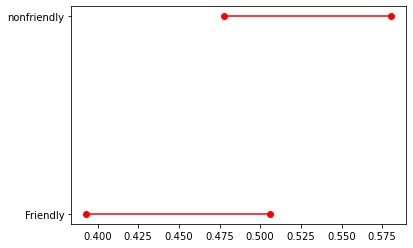

```python
import matplotlib.pyplot as plt
for lb,ub,y in zip(df_ci_egy['lb'],df_ci_egy['ub'],range(len(df_ci_egy))):
    plt.plot((lb,ub),(y,y),'ro-')
plt.yticks(range(len(df_ci_egy)),list(df_ci_egy['Typematch']))
```

```python
fra_home = df[df['home_team']=='France']
fra_away = df[df['away_team']=='France']
fra = pd.concat([fra_home, fra_away])
fra
```

|  | date | home_team | away_team | home_score | away_score | tournament | city | country | neutral | result_home | result_away |
| --- | --- | --- | --- | --- | --- | --- | --- | --- | --- | --- | --- |
| 166 | 2/12/1905 | France | Switzerland | 1 | 0 | Friendly | Paris | France | False | win | lose |
| 185 | 4/22/1906 | France | Belgium | 0 | 5 | Friendly | Saint-Cloud | France | False | lose | win |
| 215 | 4/12/1908 | France | Belgium | 1 | 2 | Friendly | Colombes | France | False | lose | win |
| 257 | 4/3/1910 | France | Belgium | 0 | 4 | Friendly | Gentilly | France | False | lose | win |
| 277 | 1/1/1911 | France | Hungary | 0 | 3 | Friendly | Maisons-Alfort | France | False | lose | win |
| ... | ... | ... | ... | ... | ... | ... | ... | ... | ... | ... | ... |
| 42475 | 6/23/2021 | Portugal | France | 2 | 2 | UEFA Euro | Budapest | Hungary | True | draw | draw |
| 42657 | 9/4/2021 | Ukraine | France | 1 | 1 | FIFA World Cup qualification | Kyiv | Ukraine | False | draw | draw |
| 42795 | 10/7/2021 | Belgium | France | 2 | 3 | UEFA Nations League | Turin | Italy | True | lose | win |
| 42858 | 10/10/2021 | Spain | France | 1 | 2 | UEFA Nations League | Milan | Italy | True | lose | win |
| 43054 | 11/16/2021 | Finland | France | 0 | 2 | FIFA World Cup qualification | Helsinki | Finland | False | lose | win |

864 rows × 11 columns